# PRACTICAL MACHINE LEARNING

**Cvp August 2017**

**Prediction Assignment Writeup**

**Final programming asignment for the Machine Learning course**

# 0. Introduction and Executive Summary

Using devices such as Jawbone Up, Nike FuelBand, and Fitbit it is now possible to collect a large amount of data about personal activity relatively inexpensively. These type of devices are part of the quantified self movement - a group of enthusiasts who take measurements about themselves regularly to improve their health, to find patterns in their behavior, or because they are tech geeks. One thing that people regularly do is quantify how much of a particular activity they do, but they rarely quantify how well they do it. In this project, your goal will be to use data from accelerometers on the belt, forearm, arm, and dumbell of 6 participants. They were asked to perform barbell lifts correctly and incorrectly in 5 different ways. More information is available from the website here: http://web.archive.org/web/20161224072740/http:/groupware.les.inf.puc-rio.br/har (see the section on the Weight Lifting Exercise Dataset).

# 1. Loading and preprocessing the data

Required libraries are loaded. Initial dimensions explored.

```r
library(caret)
library(rpart)
library(rpart.plot)

# Setting the right local working directory and loading the datasets
setwd("C:\\Users\\a212857\\Documents\\GitHub\\MachineLearning_PA")
training <- read.csv("pml-training.csv")
testing  <- read.csv("pml-testing.csv")

dim(training)
```

```
## [1] 19622   160
```

```r
dim(testing)
```

```
## [1]  20 160
```

# 2. Cleaning up

Initial dimension of the datasets includes many columns without information, training data needs to be cleaned up. First column (index) deleted because it is nor relevant for prediction pruposes.

```r
## Takes off the X (index) column not being relevant for prediction pruposes
training <- training[,-1]
testing  <- testing[,-1]

# Dataset cleanup: identify and eliminate columns with NA's in the testing dataset
emptycol <- vector(mode="numeric")
for (i in c(1:ncol(testing)))
        if (sum(is.na(testing[,i]))>1)
                emptycol <- append(emptycol, i)

# Delete columns identified in the previous step from the training and testing datasets
training1 <- training[, -emptycol]
testing1  <- testing [, -emptycol]

# Delete not complete (NA's present) rows in the testing dataset
training1 <- training1[complete.cases(training1),]
```

# 3. Cross validation

Training set is divided into train and test datasets in order to adress cross validation before prediction. 75% cases for the training set is decided.

```r
# Now we divide the training set into training and testing
inTrain <- createDataPartition(y=training1$classe, p=0.75, list=FALSE)
trainset <- training1[inTrain,]
testset  <- training1[-inTrain,]

dim(trainset)
```

```
## [1] 14718    59
```

```r
dim(testset)
```

```
## [1] 4904   59
```

# 4. Model selection, training, validation and out of sample error

Problem doens’t seem to be linear in nature, so trees are proposed. Accuracy seems to be backing up the model selection. Decision tree is plotted as well. Caret train method=“rf” was discarded as it was very slow. Accuracy reflects an acceptable out of sample error (out of sample is understood here as the validation subset split through cross validation as explained above).

```r
mod   <- rpart(classe ~ ., data=trainset, method="class")
pred  <- predict(mod, testset, type="class")

# Then calculate the confusion matrix including accuracy
confusionMatrix(pred, testset$classe)
```

```
## Confusion Matrix and Statistics
##
##           Reference
## Prediction    A    B    C    D    E
##          A 1347   36    5    1    0
##          B   32  797   51   40    0
##          C   16  111  786  128   42
##          D    0    5    8  513   63
##          E    0    0    5  122  796
##
## Overall Statistics
##
##                Accuracy : 0.8644
##                  95% CI : (0.8545, 0.8739)
##     No Information Rate : 0.2845
##     P-Value [Acc > NIR] : < 2.2e-16
##
##                   Kappa : 0.8284
##  Mcnemar's Test P-Value : NA
##
## Statistics by Class:
##
##                      Class: A Class: B Class: C Class: D Class: E
## Sensitivity            0.9656   0.8398   0.9193   0.6381   0.8835
## Specificity            0.9880   0.9689   0.9266   0.9815   0.9683
## Pos Pred Value         0.9698   0.8663   0.7258   0.8710   0.8624
## Neg Pred Value         0.9863   0.9618   0.9819   0.9326   0.9736
## Prevalence             0.2845   0.1935   0.1743   0.1639   0.1837
## Detection Rate         0.2747   0.1625   0.1603   0.1046   0.1623
## Detection Prevalence   0.2832   0.1876   0.2208   0.1201   0.1882
## Balanced Accuracy      0.9768   0.9044   0.9230   0.8098   0.9259
```

```r
# Plots the decision tree
print(mod)
```

```
## n= 14718
##
## node), split, n, loss, yval, (yprob)
##       * denotes terminal node
##
##  1) root 14718 10533 A (0.28 0.19 0.17 0.16 0.18)
##    2) cvtd_timestamp=02/12/2011 13:32,02/12/2011 13:33,02/12/2011 13:34,02/12/2011 14:56,02/12/2011 14:57,05/12/2011 11:23,05/12/2011 11:24,05/12/2011 14:22,05/12/2011 14:23,28/11/2011 14:13,28/11/2011 14:14,30/11/2011 17:10,30/11/2011 17:11 9325  5140 A (0.45 0.3 0.2 0.046 0)
##      4) cvtd_timestamp=02/12/2011 13:32,02/12/2011 13:33,02/12/2011 14:56,05/12/2011 11:23,05/12/2011 14:22,28/11/2011 14:13,30/11/2011 17:10 2958   253 A (0.91 0.086 0 0 0)
##        8) raw_timestamp_part_1< 1.322833e+09 2163     0 A (1 0 0 0 0) *
##        9) raw_timestamp_part_1>=1.322833e+09 795   253 A (0.68 0.32 0 0 0)
##         18) user_name=carlitos,charles,pedro 534     0 A (1 0 0 0 0) *
##         19) user_name=adelmo 261     8 B (0.031 0.97 0 0 0) *
##      5) cvtd_timestamp=02/12/2011 13:34,02/12/2011 14:57,05/12/2011 11:24,05/12/2011 14:23,28/11/2011 14:14,30/11/2011 17:11 6367  3795 B (0.23 0.4 0.3 0.067 0)
##       10) magnet_dumbbell_z< -2.5 3119  1685 A (0.46 0.42 0.12 0.0016 0)
##         20) raw_timestamp_part_1< 1.323095e+09 2770  1336 A (0.52 0.47 0.011 0.0018 0)
##           40) magnet_dumbbell_x< -455.5 1471   356 A (0.76 0.23 0.013 0.0034 0)
##             80) raw_timestamp_part_1< 1.323084e+09 1255   140 A (0.89 0.098 0.0096 0.004 0) *
##             81) raw_timestamp_part_1>=1.323084e+09 216     7 B (0 0.97 0.032 0 0) *
##           41) magnet_dumbbell_x>=-455.5 1299   330 B (0.25 0.75 0.0085 0 0)
##             82) num_window< 68.5 221     0 A (1 0 0 0 0) *
##             83) num_window>=68.5 1078   109 B (0.091 0.9 0.01 0 0) *
##         21) raw_timestamp_part_1>=1.323095e+09 349     0 C (0 0 1 0 0) *
##       11) magnet_dumbbell_z>=-2.5 3248  1737 C (0.014 0.39 0.47 0.13 0)
##         22) magnet_dumbbell_x>=-464.5 992   233 B (0.0081 0.77 0.11 0.11 0) *
##         23) magnet_dumbbell_x< -464.5 2256   857 C (0.017 0.23 0.62 0.14 0)
##           46) pitch_belt< -43.25 206    24 B (0 0.88 0.12 0 0) *
##           47) pitch_belt>=-43.25 2050   675 C (0.019 0.16 0.67 0.15 0) *
##    3) cvtd_timestamp=02/12/2011 13:35,02/12/2011 14:58,02/12/2011 14:59,05/12/2011 11:25,05/12/2011 14:24,28/11/2011 14:15,30/11/2011 17:12 5393  2687 E (0 0.0043 0.13 0.37 0.5)
##      6) roll_belt< 125.5 3976  2009 D (0 0.0058 0.17 0.49 0.33)
##       12) roll_dumbbell< -65.14169 803   170 C (0 0.0062 0.79 0.081 0.12) *
##       13) roll_dumbbell>=-65.14169 3173  1271 D (0 0.0057 0.014 0.6 0.38)
##         26) accel_forearm_x< -75.5 1949   355 D (0 0.0092 0.012 0.82 0.16)
##           52) magnet_belt_y>=578.5 1753   194 D (0 0.01 0.013 0.89 0.087) *
##           53) magnet_belt_y< 578.5 196    35 E (0 0 0 0.18 0.82) *
##         27) accel_forearm_x>=-75.5 1224   329 E (0 0 0.017 0.25 0.73) *
##      7) roll_belt>=125.5 1417    20 E (0 0 0 0.014 0.99) *
```

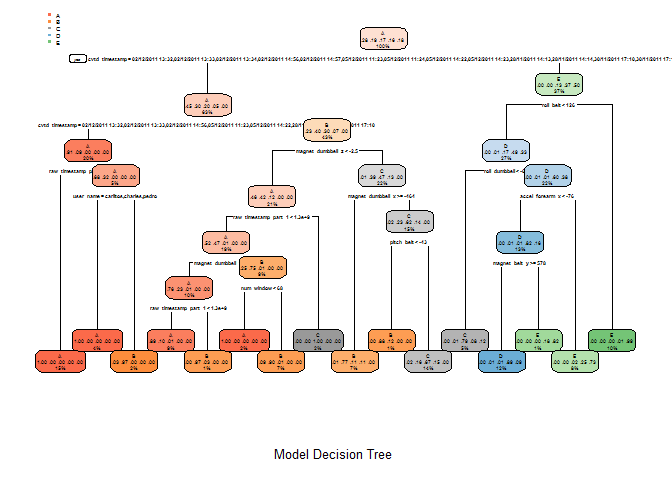

```r
#fancyRpartPlot(mod, sub="Model Decision Tree")
rpart.plot(mod, sub="Model Decision Tree", tweak=1.5)
```

## 5. Final prediction of the Testing Dataset

Final prediction is made based on the validated model

```r
# Finally we predict the testing dataset
pred  <- predict(mod, testing, type="class")
pred
```

```
##  1  2  3  4  5  6  7  8  9 10 11 12 13 14 15 16 17 18 19 20
##  B  A  C  A  A  E  D  C  A  A  B  C  B  A  E  E  A  B  B  B
## Levels: A B C D E
```